# Practical Machine Learning Week 4 - Fitness Prediction

Keith Swaback

May 22, 2017

**=========================================================================================**

# Summary

In this assignment we are asked to take the Weight Lifting Exercise data provided by the Human Activity Recognition program as described below, and to build a model using this data. Then we are asked to predict outcomes based on the model for 20 observations in a a test data set.

### Getting and cleaning the required data, creating test and training sets within the training data

Download data from the provided location. Credit should be given to the Human Activity Recognition program (“http://groupware.les.inf.puc-rio.br/har”).

We will use our training data set to build and verify our model. We will not touch the testing data until we are ready to do our predictions and submit the quiz.

The dataset for each participant includes data from 4 sensors: the “Arm”, “Belt”, “Forearm”, and “Dumbbell” sensors. Each of these sensors contains an accelerometer (3 degrees of freedom), a gyroscope (3 degrees of freedom), and a magnetometer (3 degrees of freedom). Therefore these are so-called “9 DOF sensors.”

Note that the data includes 160 variables, which includes raw data from all sensors as well as 96 “derived features” that are described in the paper associated with the Weight Lifting Exercise data.

Load the training dataset:

```r
library(RCurl)
```

```r
trainRaw <- read.csv(url('https://d396qusza40orc.cloudfront.net/predmachlearn/pml-training.csv'))
```

Now, note that the test data set that we will use to predict outcomes does not include any of the derived features, since these are all “instantaneous” samples. All the dervies features are NA. THerefore, it makes no sense to build our model to use them. Instead, let’s subset the training data to include only the columns that are relevant for our model - namely, the raw signal. Remove timestamp data and sequence data. Then remove derived feature columns (which are all NA in the test set anyway).

```r
library(caret)
trainSS <- subset(trainRaw, select = -c(X, cvtd_timestamp, raw_timestamp_part_1, raw_timestamp_part_2))
trainSmall <- trainSS[,c(1:7, 33:45, 56:64, 80:82, 98, 109:120, 136, 147:156)]
```

Choosing the features for our model can be a sophisticated exercise if we’re trying to optimize the speed of the algorithm. In this case, let’s just pick some features and run a couple qplots showing the feature values separated by classe; this will give us a quick idea of whether these features can be used. A couple examples are below:

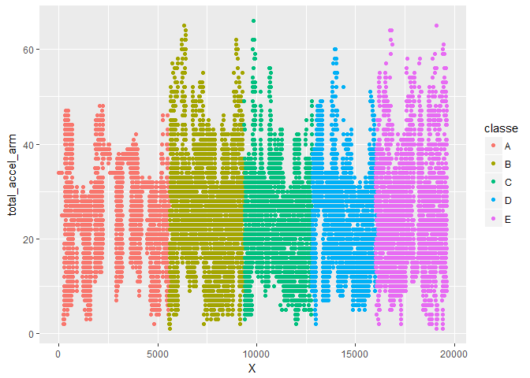

```r
qplot(data = trainRaw, x = X, y = total_accel_arm, colour = classe)
```

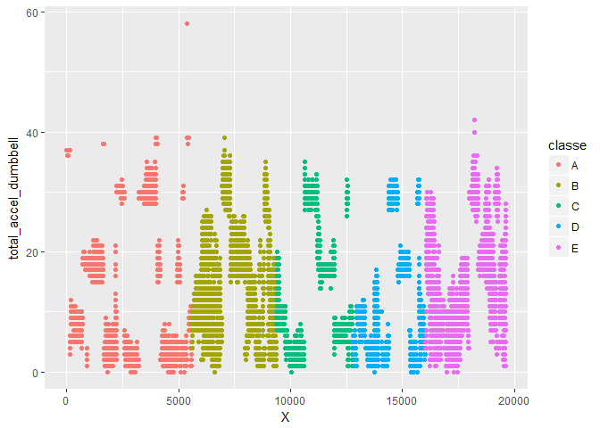

```r
qplot(data = trainRaw, x = X, y = total_accel_dumbbell, colour = classe)
```

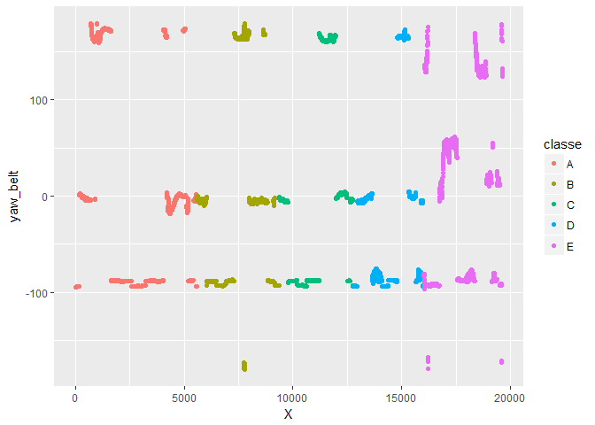

```r
qplot(data = trainRaw, x = X, y = yaw_belt, colour = classe)
```

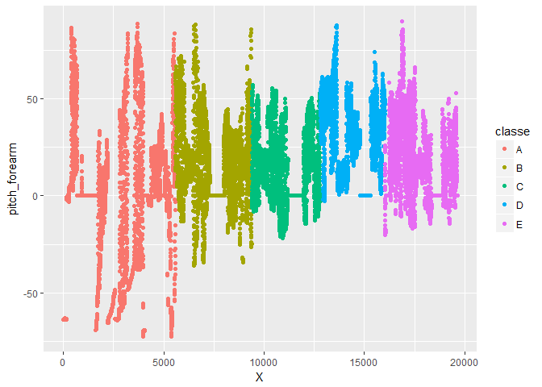

```r
qplot(data = trainRaw, x = X, y = pitch_forearm, colour = classe)
```

```r
require(dplyr)
set.seed(12345)
trainSmall <- sample_n(trainSmall, 2000)
model <- train(classe ~ ., method = "rf", data=trainSmall, prox = TRUE)
model
```

```
## Random Forest
##
## 2000 samples
##   55 predictor
##    5 classes: 'A', 'B', 'C', 'D', 'E'
##
## No pre-processing
## Resampling: Bootstrapped (25 reps)
## Summary of sample sizes: 2000, 2000, 2000, 2000, 2000, 2000, ...
## Resampling results across tuning parameters:
##
##   mtry  Accuracy   Kappa
##    2    0.9331741  0.9157607
##   30    0.9548662  0.9430841
##   59    0.9464649  0.9324888
##
## Accuracy was used to select the optimal model using  the largest value.
## The final value used for the model was mtry = 30.
```

Considering the output above, we see that the random forest algorithm maximizes accuracy well above 90% using random forest model. Therefore I expect my out of sample accuracy to also exceed 90%.  
I use this built algorithm to predict outcomes on test dataset. Results are as shown and were submitted to the course quiz.

```r
test <- read.csv(url('https://d396qusza40orc.cloudfront.net/predmachlearn/pml-testing.csv'))
predict(model, test)
```

```
##  [1] B A B A A E D B A A B C B A E E A A B B
## Levels: A B C D E
```